## One Sample t-test ( Manually )

> *Question: Is the average speed of cars that drive down Reservoir Rd. in* *Harrisonburg, Virgina more than 5 miles per hour (mph) above the speed limit ?*
- Step 0: Check your assumptions
- Step 1: Set Null and alternate hypothesis
- Step 2: Choose alpha, Level of Significance
- Step 3: Calcualte the Test Statistic
- Step 4: Draw a picture
- Step 5: Find the p-value
- Step 6: Is the p-value < $\alpha$ ? If so, Reject the Null
- Step 7: Also Compute a Confidence Interval to DoubleCheck

##### Step 0: Assumptions

- Random Sample
- Observations are Independent
- Sample is less than 10% of the entire population size
- Differences are nearly normal or the Sample size is atleast more than 30.
- If the sample differences aren’t normally distributed or when we have rank-ordered data instead of continuous quantitative data, we can choose **nonparametric alternative** for One sample t-test : **Wilcoxon One Sample Signed Rank test**

##### **Step 1**: Set Hypothesis

- Set null hypothesis $H_0$. mu.zero = 30 miles per hour
- Set alternate hypothesis $H_a$. sample.mean > 30 miles per hour

##### **Step 2**: Choose $\alpha$

- Set $\alpha$ = 0.05 (I will reject null, only if there is strong evidence that people are driving fast. So will be incorrect only 5 times out of 100)

```r
alpha = 0.05
```

##### **Step 3**: Calculate t-statistic

$$t = \frac{\bar{x} - \mu_0}{SE(\bar{x})} \qquad where,\enspace SE(\bar{x}) = SD(\bar{x}) / \sqrt{n}$$

```r
mu_zero = 30
sample_mean = 33
sample_sd = 5.6
nr_of_samples = 32

t = (sample_mean - mu_zero) / (sample_sd / sqrt(nr_of_samples))
print(t)
```

```
## [1] 3.03046
```

##### **Step 4**: Plot the Sampling Distribution of mean

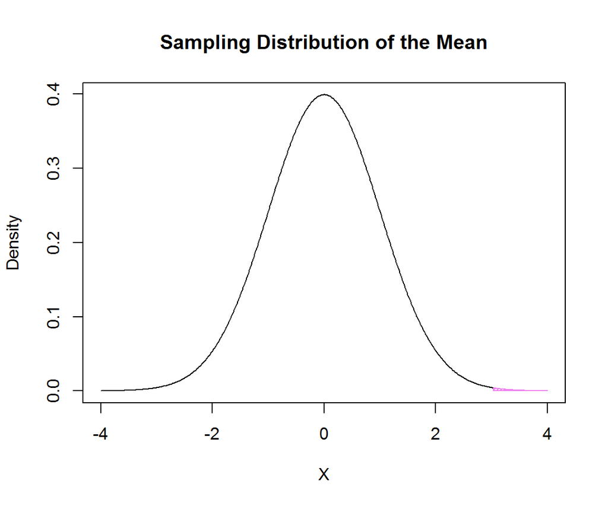

##### **Step 5**: Calculate `P-Value`

> *To calcuate the P-value for t-distribution we need to know the degree of freedom. For One sampled t-test, it can be calcuated as follows,*

$$df = nr.of.samples - 1$$

```r
df = nr_of_samples-1
p_value = 1-pt(t, df = df)  #100% of the total area under the t-distribution minus the area to the left of t-statistic.
print(p_value)
```

```
## [1] 0.00244753
```

##### **Step 6**: Is the `P-Value` < $\alpha$

```
## [1] "P-Value is less the alpha, Reject the Null Hypothesis !"
```

##### **Step 7**: Confidence Interval

$$Confidence Interval \enspace = \enspace \bar{x} \pm t_{critical} * SE(\bar{x}) \enspace = \enspace \bar{x} \pm t_{critical} * \frac{SD(\bar{x})}{\sqrt{n}}$$

- Let us first calculate critical value for our chosen $\alpha$ and degree of freedom.

```r
area = 1-(alpha/2)  #Assume alpha as 5%. 100% - 5% = 95%. To calculate 95% interval we need to find the area between (2.5% and 97.5%). So divide alpha/2 and subtract from 1 for arriving the upper limit value 0.975.

t_critical = qt(area, df = df)  #Critical value of t at 97.5%. Since t-distribution is symmetric critical value at 2.5% will be same.

sprintf("Critical value for %s%% confidence interval - One sided test is: %s",(1-alpha)*100, t_critical)
```

```
## [1] "Critical value for 95% confidence interval - One sided test is: 2.03951344639641"
```

- Now we can calcuate our confidence interval.

```r
confidence_lower_limit = sample_mean - (t_critical * sample_sd/sqrt(nr_of_samples))

confidence_upper_limit = sample_mean + (t_critical * sample_sd/sqrt(nr_of_samples))

sprintf ("%s%% Confidence level of sample mean is between %s and %s",(1-alpha)*100, confidence_lower_limit, confidence_upper_limit)
```

```
## [1] "95% Confidence level of sample mean is between 30.9809846964247 and 35.0190153035753"
```

## One Sample t-test - Using R

##### Create input samples variable.

```r
speeds = c(29, 25, 22, 34, 38, 40, 27, 29, 30, 30, 23, 34, 42, 36, 35, 27, 37)
```

##### Perform One Sample One-tail t-test

```r
t.test(speeds, mu=mu_zero, alternative="greater")
```

```
##
##  One Sample t-test
##
## data:  speeds
## t = 1.146, df = 16, p-value = 0.134
## alternative hypothesis: true mean is greater than 30
## 95 percent confidence interval:
##  29.1378     Inf
## sample estimates:
## mean of x
##   31.6471
```

> *In R, the confidence interval calculation will be different while performing one-tail test in R and not expected as we want. So to know the correct confidence interval, we need to remove the option alternative=“greater” for performing two-tailed test.*

```r
t.test(speeds, mu=mu_zero)
```

```
##
##  One Sample t-test
##
## data:  speeds
## t = 1.146, df = 16, p-value = 0.269
## alternative hypothesis: true mean is not equal to 30
## 95 percent confidence interval:
##  28.6002 34.6939
## sample estimates:
## mean of x
##   31.6471
```

> *Above is the Confidence Interval which we interested.* *Notice here the p-value got doubled, because now it accounts on both side of the tail beyond our test- statistic value. For One-tailed test, it will only account for the area greater or lesser than our test-statistic value.*